# Session 10: Real-World Data Work

- Show All Code
- Hide All Code
- View Source

R Programming Workbook

Author

R Programming Course

Published

April 29, 2026

**NoteLearning Objectives**

By the end of this session you will be able to:

1. Scrape data from HTML pages using rvest
2. Use CSS selectors to target specific page elements
3. Extract text, attributes, and tables from web pages
4. Apply the full tidyverse toolkit to solve multi-step analysis problems
5. Build an end-to-end data pipeline from messy input to clean output
6. Handle common data quality issues (inconsistent text, mixed date formats, type mismatches)
7. Wrap a pipeline into a reusable function
8. Combine dplyr, tidyr, stringr, lubridate, forcats, purrr, and ggplot2 in a single workflow

```r
library(dplyr)
library(tidyr)
library(stringr)
library(forcats)
library(lubridate)
library(purrr)
library(ggplot2)
library(rvest)
library(jsonlite)

set.seed(42)
sales <- tibble(
  date = rep(seq(as.Date("2024-01-01"), as.Date("2024-12-31"), by = "day"), 3),
  region = rep(c("North", "South", "West"), each = 366),
  product = sample(c("Widget", "Gadget", "Doohickey"), 366 * 3, replace = TRUE),
  units = rpois(366 * 3, lambda = 50),
  revenue = round(runif(366 * 3, 10, 500), 2),
  returned = rbinom(366 * 3, 1, 0.05)
)
```

## Part 1: Web Scraping with rvest

### HTML and CSS Selectors

rvest works by reading HTML and extracting elements using CSS selectors:

| Selector | Meaning |
| --- | --- |
| `h1` | All `<h1>` tags |
| `.classname` | Elements with that class |
| `#idname` | Element with that ID |
| `table td` | `<td>` elements inside `<table>` |
| `div > p` | `<p>` that are direct children of `<div>` |

### Reading and Selecting

```r
html_page <- read_html('
<html><body>
  <h1 class="main-title">Course Catalog</h1>
  <div class="course">
    <h2>Statistics 101</h2>
    <span class="credits">3 credits</span>
    <p class="desc">Introduction to statistical thinking.</p>
  </div>
  <div class="course">
    <h2>Data Science 200</h2>
    <span class="credits">4 credits</span>
    <p class="desc">Applied data analysis with R and Python.</p>
  </div>
  <div class="course">
    <h2>Machine Learning 300</h2>
    <span class="credits">4 credits</span>
    <p class="desc">Supervised and unsupervised learning methods.</p>
  </div>
</body></html>')

# Extract course names
html_page |> html_elements(".course h2") |> html_text2()
```

```
[1] "Statistics 101"       "Data Science 200"     "Machine Learning 300"
```

### Building a Tibble from Scraped Data

```r
courses <- tibble(
  name = html_page |> html_elements(".course h2") |> html_text2(),
  credits = html_page |> html_elements(".credits") |> html_text2() |>
    str_extract("\\d+") |> as.integer(),
  description = html_page |> html_elements(".desc") |> html_text2()
)

courses
```

```
# A tibble: 3 × 3
  name                 credits description
  <chr>                  <int> <chr>
1 Statistics 101             3 Introduction to statistical thinking.
2 Data Science 200           4 Applied data analysis with R and Python.
3 Machine Learning 300       4 Supervised and unsupervised learning methods.
```

Extract each field separately, then combine into a tibble.

### Extracting Tables

```r
table_html <- read_html('
<table id="grades">
  <tr><th>Student</th><th>Midterm</th><th>Final</th></tr>
  <tr><td>Alice</td><td>92</td><td>88</td></tr>
  <tr><td>Bob</td><td>78</td><td>85</td></tr>
  <tr><td>Carlos</td><td>95</td><td>91</td></tr>
</table>')

table_html |> html_table() |> pluck(1)
```

```
# A tibble: 3 × 3
  Student Midterm Final
  <chr>     <int> <int>
1 Alice        92    88
2 Bob          78    85
3 Carlos       95    91
```

`html_table()` converts HTML tables to data frames directly.

### Extracting Links

```r
link_html <- read_html('
<ul class="resources">
  <li><a href="https://r-project.org">R Project</a></li>
  <li><a href="https://tidyverse.org">Tidyverse</a></li>
  <li><a href="https://quarto.org">Quarto</a></li>
</ul>')

tibble(
  text = link_html |> html_elements(".resources a") |> html_text2(),
  url = link_html |> html_elements(".resources a") |> html_attr("href")
)
```

```
# A tibble: 3 × 2
  text      url
  <chr>     <chr>
1 R Project https://r-project.org
2 Tidyverse https://tidyverse.org
3 Quarto    https://quarto.org
```

**NoteBase R vs Tidyverse**

Base R does not have built-in web scraping tools. The xml2 package (which rvest builds on) provides the low-level XML/HTML parsing. rvest adds the user-friendly `html_elements()`, `html_text2()`, and `html_table()` wrappers.

### Your Turn: Exercise 1

Extract the product names and prices from this HTML:

```r
shop_html <- read_html('
<div class="shop">
  <div class="item"><span class="name">Laptop</span><span class="price">$999</span></div>
  <div class="item"><span class="name">Mouse</span><span class="price">$29</span></div>
  <div class="item"><span class="name">Keyboard</span><span class="price">$79</span></div>
  <div class="item"><span class="name">Monitor</span><span class="price">$349</span></div>
</div>')
```

Build a tibble with columns `name` (character) and `price` (numeric).

**Solution**

```r
tibble(
  name = shop_html |> html_elements(".name") |> html_text2(),
  price = shop_html |> html_elements(".price") |> html_text2() |>
    str_remove("\\$") |> as.numeric()
)
```

```
# A tibble: 4 × 2
  name     price
  <chr>    <dbl>
1 Laptop     999
2 Mouse       29
3 Keyboard    79
4 Monitor    349
```

### Your Turn: Exercise 2

Extract the table from this HTML and compute each student’s average score:

```r
score_html <- read_html('
<table>
  <tr><th>Name</th><th>Quiz1</th><th>Quiz2</th><th>Quiz3</th></tr>
  <tr><td>Diana</td><td>85</td><td>90</td><td>88</td></tr>
  <tr><td>Elena</td><td>92</td><td>87</td><td>95</td></tr>
  <tr><td>Frank</td><td>78</td><td>82</td><td>80</td></tr>
</table>')
```

**Solution**

```r
scores <- score_html |> html_table() |> pluck(1)

scores |>
  mutate(across(starts_with("Quiz"), as.numeric)) |>
  rowwise() |>
  mutate(average = mean(c_across(starts_with("Quiz")))) |>
  ungroup()
```

```
# A tibble: 3 × 5
  Name  Quiz1 Quiz2 Quiz3 average
  <chr> <dbl> <dbl> <dbl>   <dbl>
1 Diana    85    90    88    87.7
2 Elena    92    87    95    91.3
3 Frank    78    82    80    80
```

### Your Turn: Exercise 3

Extract all links from this HTML and filter to only external links (those starting with “http”):

```r
nav_html <- read_html('
<nav>
  <a href="/">Home</a>
  <a href="/about">About</a>
  <a href="https://github.com/example">GitHub</a>
  <a href="/contact">Contact</a>
  <a href="https://docs.example.com">Documentation</a>
</nav>')
```

**Solution**

```r
all_links <- tibble(
  text = nav_html |> html_elements("a") |> html_text2(),
  url = nav_html |> html_elements("a") |> html_attr("href")
)

all_links |> filter(str_starts(url, "http"))
```

```
# A tibble: 2 × 2
  text          url
  <chr>         <chr>
1 GitHub        https://github.com/example
2 Documentation https://docs.example.com
```

**WarningCommon Mistake**

Using `html_text()` instead of `html_text2()`:

```r
# html_text() preserves internal whitespace/newlines (often messy)
# html_text2() simulates how text looks in a browser (cleaner)
```

Always prefer `html_text2()` unless you need the raw whitespace.

**TipChallenge**

Scrape this nested HTML and build a tibble with team name, wins, and losses. Compute win percentage.

```r
standings_html <- read_html('
<div class="standings">
  <div class="team">
    <h3>Eagles</h3>
    <span class="record"><span class="wins">10</span>-<span class="losses">4</span></span>
  </div>
  <div class="team">
    <h3>Hawks</h3>
    <span class="record"><span class="wins">8</span>-<span class="losses">6</span></span>
  </div>
  <div class="team">
    <h3>Bears</h3>
    <span class="record"><span class="wins">12</span>-<span class="losses">2</span></span>
  </div>
</div>')
```

**Solution**

```r
tibble(
  team = standings_html |> html_elements(".team h3") |> html_text2(),
  wins = standings_html |> html_elements(".wins") |> html_text2() |> as.integer(),
  losses = standings_html |> html_elements(".losses") |> html_text2() |> as.integer()
) |>
  mutate(win_pct = round(wins / (wins + losses), 3))
```

```
# A tibble: 3 × 4
  team    wins losses win_pct
  <chr>  <int>  <int>   <dbl>
1 Eagles    10      4   0.714
2 Hawks      8      6   0.571
3 Bears     12      2   0.857
```

## Part 2: Tidyverse Cumulative Practice

### Practice Problem 1: Seasonal Analysis

Find the season (Spring: Mar-May, Summer: Jun-Aug, Fall: Sep-Nov, Winter: Dec-Feb) with the highest average daily revenue.

**Solution**

```r
sales |>
  mutate(
    month_num = month(date),
    season = case_when(
      month_num %in% 3:5 ~ "Spring",
      month_num %in% 6:8 ~ "Summer",
      month_num %in% 9:11 ~ "Fall",
      TRUE ~ "Winter"
    )
  ) |>
  summarize(avg_daily_revenue = mean(revenue), .by = season) |>
  arrange(desc(avg_daily_revenue))
```

```
# A tibble: 4 × 2
  season avg_daily_revenue
  <chr>              <dbl>
1 Fall                270.
2 Spring              262.
3 Summer              261.
4 Winter              255.
```

### Practice Problem 2: Return Rate Heatmap

Create a heatmap of return rate by month and region.

**Solution**

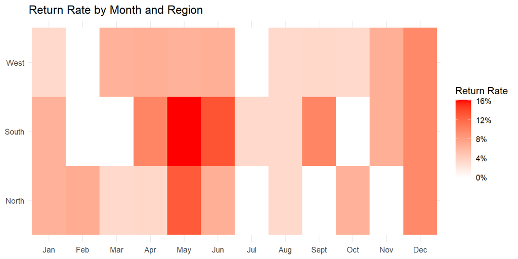

```r
sales |>
  mutate(month_name = month(date, label = TRUE)) |>
  summarize(return_rate = mean(returned), .by = c(month_name, region)) |>
  ggplot(aes(x = month_name, y = region, fill = return_rate)) +
  geom_tile() +
  scale_fill_gradient(low = "white", high = "red", labels = scales::percent) +
  labs(title = "Return Rate by Month and Region", x = NULL, y = NULL, fill = "Return Rate") +
  theme_minimal()
```

### Practice Problem 3: Product Performance Ranking

Rank products by total revenue within each region. Show the rank as a new column.

**Solution**

```r
sales |>
  summarize(total_revenue = sum(revenue), .by = c(region, product)) |>
  mutate(rank = min_rank(desc(total_revenue)), .by = region) |>
  arrange(region, rank)
```

```
# A tibble: 9 × 4
  region product   total_revenue  rank
  <chr>  <chr>             <dbl> <int>
1 North  Gadget           36365.     1
2 North  Widget           31857.     2
3 North  Doohickey        27180.     3
4 South  Gadget           33872.     1
5 South  Doohickey        31637.     2
6 South  Widget           30925.     3
7 West   Doohickey        33225.     1
8 West   Gadget           32874.     2
9 West   Widget           29708.     3
```

### Practice Problem 4: Rolling 7-Day Average

Compute a 7-day rolling average of daily revenue for the North region.

**Solution**

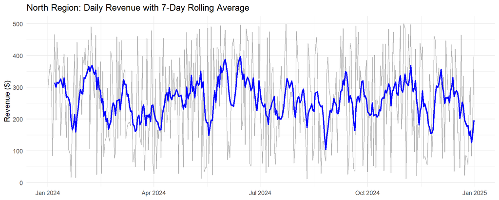

```r
north_daily <- sales |>
  filter(region == "North") |>
  summarize(daily_revenue = sum(revenue), .by = date) |>
  arrange(date) |>
  mutate(
    rolling_avg = slider::slide_dbl(daily_revenue, mean, .before = 6, .complete = TRUE)
  )

ggplot(north_daily, aes(x = date)) +
  geom_line(aes(y = daily_revenue), alpha = 0.3) +
  geom_line(aes(y = rolling_avg), color = "blue", linewidth = 1) +
  labs(title = "North Region: Daily Revenue with 7-Day Rolling Average",
       x = NULL, y = "Revenue ($)") +
  theme_minimal()
```

### Practice Problem 5: Per-Group Models

Fit a linear model of revenue ~ units for each product. Report the slope and R-squared.

**Solution**

```r
sales |>
  nest(.by = product) |>
  mutate(
    model = map(data, \(df) lm(revenue ~ units, data = df)),
    slope = map_dbl(model, \(m) coef(m)["units"]),
    r_squared = map_dbl(model, \(m) summary(m)$r.squared)
  ) |>
  select(product, slope, r_squared) |>
  arrange(desc(r_squared))
```

```
# A tibble: 3 × 3
  product     slope  r_squared
  <chr>       <dbl>      <dbl>
1 Widget    -2.41   0.0149
2 Doohickey -1.90   0.00980
3 Gadget    -0.0283 0.00000206
```

### Your Turn: Exercise 4

Find the day of the week with the highest total sales (units). Create a bar chart showing total units by day of week.

**Solution**

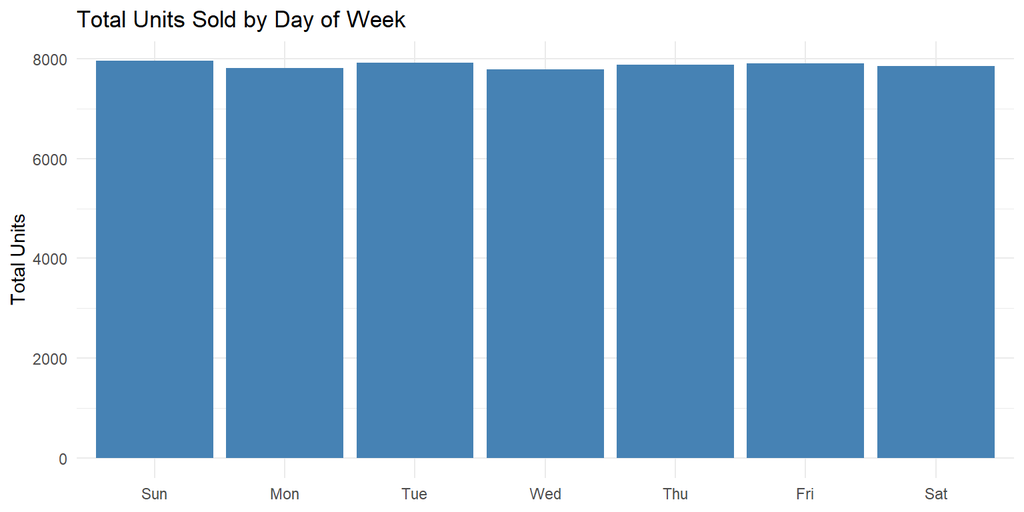

```r
sales |>
  mutate(weekday = wday(date, label = TRUE)) |>
  summarize(total_units = sum(units), .by = weekday) |>
  ggplot(aes(x = weekday, y = total_units)) +
  geom_col(fill = "steelblue") +
  labs(title = "Total Units Sold by Day of Week", x = NULL, y = "Total Units") +
  theme_minimal()
```

### Your Turn: Exercise 5

For each region, find the month with the highest revenue and the month with the lowest revenue. Return a tibble with columns: region, best_month, worst_month.

**Solution**

```r
monthly <- sales |>
  mutate(month_name = month(date, label = TRUE)) |>
  summarize(total_rev = sum(revenue), .by = c(region, month_name))

best <- monthly |> slice_max(total_rev, n = 1, by = region) |> select(region, best_month = month_name)
worst <- monthly |> slice_min(total_rev, n = 1, by = region) |> select(region, worst_month = month_name)

inner_join(best, worst, by = "region")
```

```
# A tibble: 3 × 3
  region best_month worst_month
  <chr>  <ord>      <ord>
1 North  Jun        Mar
2 South  Nov        Jan
3 West   Oct        Feb
```

**WarningCommon Mistake**

Using `group_by()` without `ungroup()`:

```r
sales |>
  group_by(region) |>
  mutate(pct = revenue / sum(revenue))
# Next operation is still grouped! Can cause unexpected behavior.
```

Prefer `.by` in `summarize()` and `mutate()` to avoid forgotten groups.

## Part 3: End-to-End Pipeline

### The Messy Dataset

```r
messy <- tibble(
  order_date = c("2024-01-15", "2024/02/20", "March 5, 2024", "2024-04-10",
                 "2024-05-22", "2024-06-30", NA, "2024-08-15"),
  customer = c("alice smith", "BOB JONES", "Carlos M.", " diana Lee",
               "Elena Wu", "FRANK o'brien", "alice smith", "Bob Jones"),
  item = c("Widget_Pro", "gadget-basic", "WIDGET PRO", "Doohickey Ultra",
           "widget_pro", "Gadget Basic", "DOOHICKEY_ULTRA", "Widget Pro"),
  quantity = c("5", "three", "2", "10", "7", "4", "6", "8"),
  amount = c(149.95, 29.97, NA, 199.90, 209.65, 59.96, 179.94, 239.92),
  status = c("shipped", "DELIVERED", "Shipped", "pending", "SHIPPED",
             "Delivered", "cancelled", "PENDING")
)

messy
```

```
# A tibble: 8 × 6
  order_date    customer        item            quantity amount status
  <chr>         <chr>           <chr>           <chr>     <dbl> <chr>
1 2024-01-15    "alice smith"   Widget_Pro      5         150.  shipped
2 2024/02/20    "BOB JONES"     gadget-basic    three      30.0 DELIVERED
3 March 5, 2024 "Carlos M."     WIDGET PRO      2          NA   Shipped
4 2024-04-10    " diana Lee"    Doohickey Ultra 10        200.  pending
5 2024-05-22    "Elena Wu"      widget_pro      7         210.  SHIPPED
6 2024-06-30    "FRANK o'brien" Gadget Basic    4          60.0 Delivered
7 <NA>          "alice smith"   DOOHICKEY_ULTRA 6         180.  cancelled
8 2024-08-15    "Bob Jones"     Widget Pro      8         240.  PENDING
```

### Your Turn: Exercise 6 (Pipeline Project)

Clean this dataset. Your final tibble should have:

- `order_date` as a proper Date
- `customer` in title case with trimmed whitespace
- `item` cleaned to consistent format (title case, spaces instead of underscores/hyphens)
- `quantity` as numeric (handle the text “three” -> NA or 3)
- `amount` with NAs handled
- `status` as a factor with levels: pending, shipped, delivered, cancelled

**Solution**

```r
word_to_num <- function(x) {
  words <- c(one = 1, two = 2, three = 3, four = 4, five = 5,
             six = 6, seven = 7, eight = 8, nine = 9, ten = 10)
  x_lower <- str_to_lower(x)
  ifelse(x_lower %in% names(words), words[x_lower], suppressWarnings(as.numeric(x)))
}

clean <- messy |>
  mutate(
    order_date = parse_date_time(order_date, orders = c("ymd", "y/m/d", "mdy")) |> as_date(),
    customer = str_trim(customer) |> str_to_title(),
    item = str_replace_all(item, "[_-]", " ") |> str_to_title(),
    quantity = word_to_num(quantity),
    amount = coalesce(amount, median(amount, na.rm = TRUE)),
    status = str_to_lower(status) |>
      factor(levels = c("pending", "shipped", "delivered", "cancelled"))
  ) |>
  filter(!is.na(order_date))

clean
```

```
# A tibble: 7 × 6
  order_date customer      item            quantity amount status
  <date>     <chr>         <chr>              <dbl>  <dbl> <fct>
1 2024-01-15 Alice Smith   Widget Pro             5  150.  shipped
2 2024-02-20 Bob Jones     Gadget Basic           3   30.0 delivered
3 2024-03-05 Carlos M.     Widget Pro             2  180.  shipped
4 2024-04-10 Diana Lee     Doohickey Ultra       10  200.  pending
5 2024-05-22 Elena Wu      Widget Pro             7  210.  shipped
6 2024-06-30 Frank O'brien Gadget Basic           4   60.0 delivered
7 2024-08-15 Bob Jones     Widget Pro             8  240.  pending
```

### Your Turn: Exercise 7

Using your cleaned data from Exercise 6, answer:

1. How many orders per status?
2. Which customer has the highest total amount?
3. Which item is most popular by quantity?

**Solution**

```r
# 1. Orders per status
clean |> count(status)
```

```
# A tibble: 3 × 2
  status        n
  <fct>     <int>
1 pending       2
2 shipped       3
3 delivered     2
```

**Solution**

```r
# 2. Highest total by customer
clean |>
  summarize(total = sum(amount), .by = customer) |>
  slice_max(total, n = 1)
```

```
# A tibble: 1 × 2
  customer  total
  <chr>     <dbl>
1 Bob Jones  270.
```

**Solution**

```r
# 3. Most popular item
clean |>
  summarize(total_qty = sum(quantity, na.rm = TRUE), .by = item) |>
  slice_max(total_qty, n = 1)
```

```
# A tibble: 1 × 2
  item       total_qty
  <chr>          <dbl>
1 Widget Pro        22
```

### Your Turn: Exercise 8

Wrap your cleaning logic from Exercise 6 into a function called `clean_orders` that accepts a raw tibble and returns the cleaned version. Test it on the original `messy` data.

**Solution**

```r
clean_orders <- function(raw) {
  word_to_num <- function(x) {
    words <- c(one = 1, two = 2, three = 3, four = 4, five = 5,
               six = 6, seven = 7, eight = 8, nine = 9, ten = 10)
    x_lower <- str_to_lower(x)
    ifelse(x_lower %in% names(words), words[x_lower], suppressWarnings(as.numeric(x)))
  }

  raw |>
    mutate(
      order_date = parse_date_time(order_date, orders = c("ymd", "y/m/d", "mdy")) |> as_date(),
      customer = str_trim(customer) |> str_to_title(),
      item = str_replace_all(item, "[_-]", " ") |> str_to_title(),
      quantity = word_to_num(quantity),
      amount = coalesce(amount, median(amount, na.rm = TRUE)),
      status = str_to_lower(status) |>
        factor(levels = c("pending", "shipped", "delivered", "cancelled"))
    ) |>
    filter(!is.na(order_date))
}

clean_orders(messy)
```

```
# A tibble: 7 × 6
  order_date customer      item            quantity amount status
  <date>     <chr>         <chr>              <dbl>  <dbl> <fct>
1 2024-01-15 Alice Smith   Widget Pro             5  150.  shipped
2 2024-02-20 Bob Jones     Gadget Basic           3   30.0 delivered
3 2024-03-05 Carlos M.     Widget Pro             2  180.  shipped
4 2024-04-10 Diana Lee     Doohickey Ultra       10  200.  pending
5 2024-05-22 Elena Wu      Widget Pro             7  210.  shipped
6 2024-06-30 Frank O'brien Gadget Basic           4   60.0 delivered
7 2024-08-15 Bob Jones     Widget Pro             8  240.  pending
```

### Think About It

You receive a CSV file every week with the same structure but different data. Your boss wants a weekly report with summary stats and charts. How would you structure your R project to handle this? What would you put in functions vs. scripts vs. Quarto documents?

**TipChallenge**

Build a complete mini-pipeline: scrape the product data below, clean it, join it with order data, and produce a summary.

```r
product_html <- read_html('
<table id="catalog">
  <tr><th>Product</th><th>Category</th><th>Base Price</th></tr>
  <tr><td>Widget Pro</td><td>Hardware</td><td>$29.99</td></tr>
  <tr><td>Gadget Basic</td><td>Electronics</td><td>$9.99</td></tr>
  <tr><td>Doohickey Ultra</td><td>Accessories</td><td>$29.99</td></tr>
</table>')

order_data <- tibble(
  product = c("Widget Pro", "Gadget Basic", "Widget Pro",
              "Doohickey Ultra", "Gadget Basic", "Widget Pro"),
  quantity = c(5, 3, 2, 10, 7, 4),
  date = as.Date(c("2024-01-15", "2024-01-20", "2024-02-05",
                    "2024-02-10", "2024-03-01", "2024-03-15"))
)
```

**Solution**

```r
# Step 1: Scrape product catalog
catalog <- product_html |>
  html_table() |>
  pluck(1) |>
  as_tibble() |>
  mutate(
    `Base Price` = str_remove(`Base Price`, "\\$") |> as.numeric()
  ) |>
  rename(product = Product, category = Category, base_price = `Base Price`)

# Step 2: Join with orders
enriched_orders <- order_data |>
  left_join(catalog, by = "product") |>
  mutate(
    total = quantity * base_price,
    month = floor_date(date, "month")
  )

# Step 3: Summary
enriched_orders |>
  summarize(
    total_revenue = sum(total),
    total_units = sum(quantity),
    avg_order_value = mean(total),
    .by = c(category, month)
  ) |>
  arrange(month, category)
```

```
# A tibble: 6 × 5
  category    month      total_revenue total_units avg_order_value
  <chr>       <date>             <dbl>       <dbl>           <dbl>
1 Electronics 2024-01-01          30.0           3            30.0
2 Hardware    2024-01-01         150.            5           150.
3 Accessories 2024-02-01         300.           10           300.
4 Hardware    2024-02-01          60.0           2            60.0
5 Electronics 2024-03-01          69.9           7            69.9
6 Hardware    2024-03-01         120.            4           120.
```

## Session Synthesis

### Connect the Dots

Build a full pipeline that:

1. Scrapes this employee directory HTML
2. Cleans and standardizes the data
3. Joins with performance data
4. Produces a summary report with a visualization

```r
directory_html <- read_html('
<div class="directory">
  <div class="employee">
    <h3>Alice Chen</h3>
    <span class="dept">Engineering</span>
    <span class="hire-date">2020-03-15</span>
  </div>
  <div class="employee">
    <h3>Bob Martinez</h3>
    <span class="dept">Marketing</span>
    <span class="hire-date">2019-08-01</span>
  </div>
  <div class="employee">
    <h3>Carlos Lee</h3>
    <span class="dept">Engineering</span>
    <span class="hire-date">2021-01-10</span>
  </div>
  <div class="employee">
    <h3>Diana Patel</h3>
    <span class="dept">Marketing</span>
    <span class="hire-date">2022-06-20</span>
  </div>
</div>')

performance <- tibble(
  name = c("Alice Chen", "Bob Martinez", "Carlos Lee", "Diana Patel"),
  q1_score = c(92, 78, 88, 95),
  q2_score = c(88, 82, 91, 90),
  q3_score = c(95, 80, 85, 93),
  q4_score = c(90, 85, 89, 97)
)
```

**Solution**

```r
# 1. Scrape directory
employees <- tibble(
  name = directory_html |> html_elements(".employee h3") |> html_text2(),
  department = directory_html |> html_elements(".dept") |> html_text2(),
  hire_date = directory_html |> html_elements(".hire-date") |> html_text2() |> as_date()
)

# 2. Join with performance
full_data <- employees |>
  left_join(performance, by = "name") |>
  mutate(tenure_years = as.numeric(Sys.Date() - hire_date) / 365.25)

# 3. Compute yearly average
full_data <- full_data |>
  rowwise() |>
  mutate(avg_score = mean(c_across(starts_with("q")))) |>
  ungroup()

# 4. Summary
full_data |>
  summarize(
    n_employees = n(),
    avg_performance = mean(avg_score),
    avg_tenure = mean(tenure_years),
    .by = department
  )
```

```
# A tibble: 2 × 4
  department  n_employees avg_performance avg_tenure
  <chr>             <int>           <dbl>      <dbl>
1 Engineering           2            89.8       5.71
2 Marketing             2            87.5       5.30
```

**Solution**

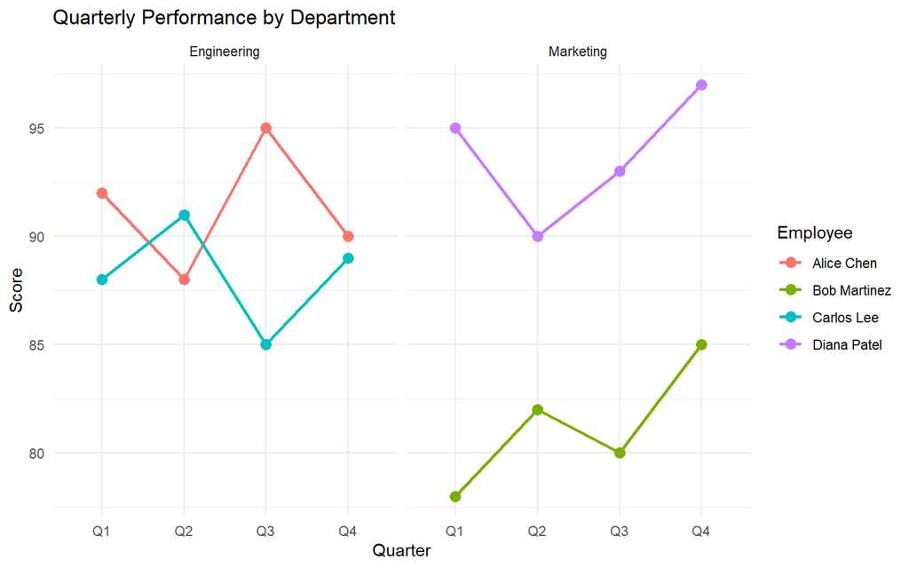

```r
# 5. Visualization
full_data |>
  pivot_longer(cols = starts_with("q"), names_to = "quarter", values_to = "score") |>
  mutate(quarter = str_remove(quarter, "_score") |> str_to_upper()) |>
  ggplot(aes(x = quarter, y = score, color = name, group = name)) +
  geom_line(linewidth = 1) +
  geom_point(size = 3) +
  facet_wrap(~department) +
  labs(title = "Quarterly Performance by Department",
       x = "Quarter", y = "Score", color = "Employee") +
  theme_minimal()
```

### Key Takeaways

- rvest follows a read -> select -> extract pattern for web scraping.
- Real data requires cleaning. Expect inconsistent text, dates, types, and missing values.
- A good data pipeline is a function: raw data in, analysis-ready data out.
- You now have the full tidyverse toolkit: dplyr, tidyr, stringr, forcats, lubridate, purrr, ggplot2, rvest, httr2, jsonlite.

### Prepare for Next Session

Session 11 introduces Quarto. You will learn to turn your R analysis into polished HTML documents, PDFs, and Word files. Review how code chunks work (you have been using them in every workbook). Bring a short analysis you would like to turn into a report.